# Mixed Strategies

with Connor T. Wiegand

## Admin

### Due Dates

- Deadline for homework 4 is getting moved up to Friday, June 7th, with **no** grace period
  - Final exam on Monday
  - I want you to have access to the answer key over the weekend
- Project due date getting moved back to Tuesday of finals week

## Mixed strategies

### Recall

- Earlier in the term, I suggested that we can think about agent’s playing *non-deterministically*
  - Sometimes I play one thing, sometimes I play another
  - ex: Rock, Paper, Scissors
- To model this, we need only think about the probability that a player plays a certain (pure) strategy
  - If $s_1$ and $s_2$ are my pure strategies, then one mixed strategy I could play is
    $$\frac{1}{3}s_1+\frac{2}{3}s_2$$
  - *I play $s_1$ a one third of time, and I play $s_2$ two thirds of the time*

### Ex: Matching Pennies

- Sean’s pure strategies: $S_1=\{H, T\}$
- Examples of Sean’s mixed strategies:
  - $(1/6)H + (5/6)T$
  - $(5/8)H + (3/8)T$
- In general:
  - $pH + qT$, where $p$ and $q$ are probabilities

### Pause: what’s a probability?

- $\{p_1, \dots, p_k\}$ are valid probabilities provided that
  - All $p$’s are non-negative
    - $p_j\ge 0$ for all $j$
  - All $p$’s are (weakly) smaller than 1
    - $p_j\le 1$ for all $j$
  - $p$’s sum to 1
    - $$\sum_{j=1}^{k}p_j=p_1+\cdots+p_k=1$$

### Ex: Matching Pennies (cont.)

- Sean’s pure strategies: $S_1=\{H, T\}$
- Examples of Sean’s mixed strategies:
  - $(1/6)H + (5/6)T$
  - $(5/8)H + (3/8)T$
  - $pH + qT$, where $p$ and $q$ are probabilities
- **Question**: can we simplify this general mixed strategy?
  - *Hint*: do we need both $p$ and $q$?

### # of Parameters

- Consider $pH + qT$; what’s true about $p$ and $q$?
  - $p,q\ge 0$
  - $p,q \le 1$
  - $p+q=1$
- Based on the last point, we can rewrite $q$ as
  $$q=1-p$$
- Using this, let’s rewrite Sean’s strategy as
  $$pH+(1-p)T$$
  - Now, Sean’s mixed strategy can be written using only 1 parameter
  - In general, a mixed strategy composed of $m$ pure strategies only needs $m-1$ probabilities

### Interpreting Mixed Strategies

- Sean’s mixed strategy: $pH+(1-p)T$
  - What happens when $p=0$?
    - $0H+(1-0)T=0H+1T=T$
    - Sean plays Tails all the time
  - What happens when $p=1$?
    - $1H+(1-1)T=1H+0T=H$
    - Sean plays Heads all the time
- Technically, any pure strategy is a (degenerate) mixed strategy
  - If we want to be certain that we aren’t talking about pure strategies, we might use the term **truly mixed strategy**
    - However, we can often get away with just using *mixed strategy* and understanding what we mean based on context

### Notation

- If $S_i=\{s_1, \dots, s_{k}\}$ denotes a player’s pure strategies in a game
- Then $\Sigma_i$ denotes a player’s mixed strategies in a game
  - An example strategy, call it $\sigma$, takes the form
    $$\sigma=p_1 s_1 + \dots + p_k s_k$$

    where $p_\ell$ are probabilities
- Limiting ourselves to 2-player games, we can typcially get away with $p, q, r$ for probabilities, and $\sigma$, $\tau$<sup>1</sup> for the names of mixed strategies
- Again: a **truly mixed strategy** is one where there is no $p_\ell=1$
- Similarly, a **totally** **mixed strategy** is one where there is no $p_\ell=0$
  - That is, every pure strategy a player has gets played with positive probability
  - This term will also rarely be used
[^1]: *sigma* and *tau*

### Ex

- General Mixed Strategy:

  $$\sigma=p_X X + p_Y Y + p_Z Z$$
- Example of truly, not totally mixed strategy:

  $$\hat\sigma=0.35X+0.65Z$$
- Example of totally mixed strategy:

  $$\tilde\sigma=0.3X+0.1Y+0.6Z$$

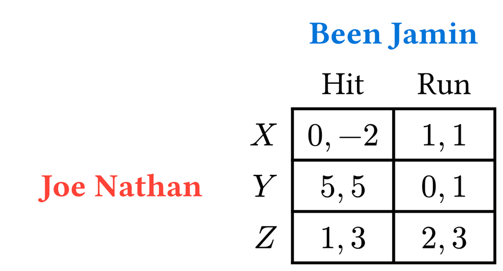

## Context

### Setting

- Where do mixed strategies exist?
  - Everywhere, but we will limit our discussion to 2-player normal form games
  - If I ask you for all NE of a normal form game, I mean both mixed and pure-strategy
  - On the other hand, if I ask for all NE in an extensive form game, I mean both vanilla (pure-strategy) and subgame-perfect
    - I’ll never ask for mixed strategies in extensive form games, even though we could talk about them

### The importance of mixed strategies

- What Nash did for his dissertation is show that, when we allow for mixed strategies, every “reasonable”<sup>1</sup> game has *some* Nash equilibrium
- Remarks
  - I want you to assume that every game I show you in this class is “reasonable”
  - In particular, I’m never looking for the answer “this game does not have any NE”
  - Maybe none *of a certain flavor* or *class*, but not “none”
- Reminder: What is a NE?
  - Intersection of Best Responses
[^2]: See week 3 notes for definition

## When would someone mix?

### Example

- Let’s return to matching pennies:
- Let’s assume – for whatever reason – that Sean is playing *some* mixed strategy $\sigma=pH+(1-p)T$
  - $p$: prob. of playing Heads
  - $1-p$: prob. of playing Tails

### When will someone play a mixed strategy?

- Let’s take for granted that Sean might be playing a mixed strategy
- Given this, Bean is thinking about playing a mixed strategy as well. When does it make sense to do so?
  - Let’s compare $E[u_B(\sigma, H)]$ vs. $E[u_B(\sigma, T)]$
1. Suppose $E[u_B(\sigma, H)] > E[u_B(\sigma, T)]$
   - “Bean gets a higher e.p.<sup>1</sup> from playing H than T”
   - So: does Bean have any reason to play $T$?
     - No! That would be adding probability to a worse outcome
     - Bean should just play $H$
[^3]: expected payoff

### When will someone play a mixed strategy? (cont.)

1. Suppose $E[u_B(\sigma, H)] > E[u_B(\sigma, T)]$
   - “Bean gets a higher e.p. from playing H than T”
   - So Bean should just play $H$
2. Instead suppose $E[u_B(\sigma, H)] < E[u_B(\sigma, T)]$
   - “Bean gets a higher e.p. from playing T than H”
   - Does Bean have any reason to play $H$?
     - No! Bean should just play $T$
- Should you ever play a mixed strategy that includes quitting?
  - Not if you want to win
  - Juking out your opponent doesn’t work – even if your opponent doesn’t expect it – if you go out of bounds

### When will someone play a mixed strategy? (cont.)

1. Suppose $E[u_B(\sigma, H)] > E[u_B(\sigma, T)]$
   - Bean should just play $H$
2. Suppose $E[u_B(\sigma, H)] < E[u_B(\sigma, T)]$
   - Bean should just play $T$
3. What if $E[u_B(\sigma, H)] = E[u_B(\sigma, T)]$?
   - What does this say in words?
   - “Bean is *indifferent* between playing $H$ and $T$”
- If Bean gets equal (expected) payoffs from playing either pure strategy, then (and only then) will they have reason to play a mixed strategy
- This holds true in general:
  - An agent will only play a mixed strategy when they are indifferent between a subset of their pure strategies, *holding fixed what the other player is doing*
  - …and, assuming these strategies are the best pure strategies they can play, in response to the opponent’s strategy
    - Ex. suppose *scream* $\sim$ *cry*, but **try** is better than both

## Finding MSNE

### Start Somewhere

- Suppose Bean is playing some mixed strategy $\tau=qH+(1-q)T$
- What is $E[u_S(H, \tau)]$? $E[u_S(T, \tau)]$?
  - $E[u_S(H, \tau)]$
    $$= q \cdot u_S(H,H) + (1-q) \cdot u_S(T,H) = q(1) + (1-q)(-1) = 2q-1$$
  - $E[u_S(T, \tau)]$

    $$= q \cdot u_S(H,T) + (1-q) \cdot u_S(T,T) = q(-1)+(1-q)(1)=1-2q$$
- When will Sean (rationally) play a mixed strategy?

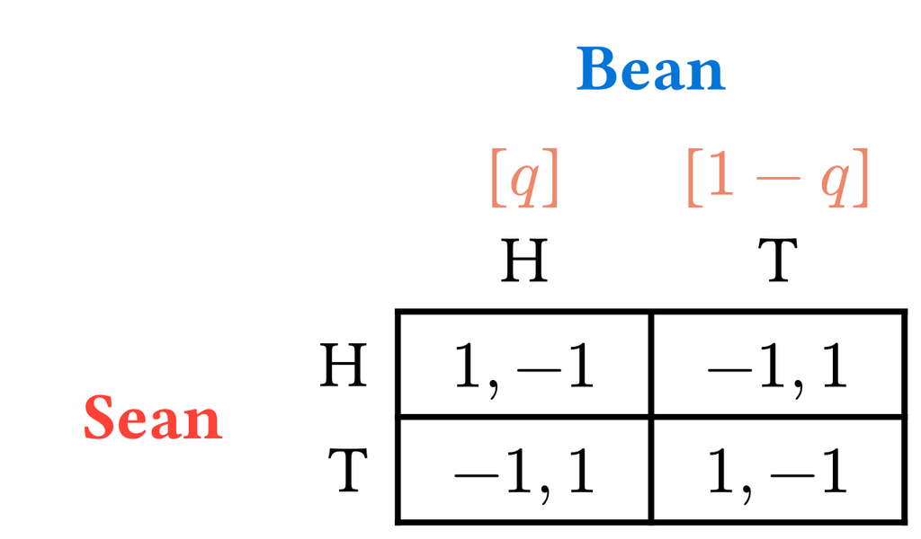

### When does Sean mix?

- $E[u_S(H, \tau)]=2q-1$
- $E[u_S(T, \tau)]=1-2q$
- When will Sean (rationally) play a mixed strategy?
  - When $E[u_S(H, \tau)] = E[u_S(T, \tau)]$
  - Why?
    - Suppose this wasn’t true… (Go back a few slides)
- $$\begin{align*}
  E[u_S(H, \tau)] &= E[u_S(T, \tau)]\\
  2q-1 &= 1-2q\\
  4q &= 2\\
  q &= \frac{1}{2}
  \end{align*}$$
- So?

### When does Sean mix? (cont.)

- Sean can rationally play a mixed strategy when $q=\frac{1}{2}$
- Remember: we assumed Bean was playing $\tau=qH+(1-q)T$
- So, Sean will mix when Bean is playing $\tau=0.5H+0.5T$

### Take it back now y’all

- Now suppose – for whatever reason – that Sean is playing some mixed strategy
  $$\sigma=pH+(1-p)T$$
- When will Bean mix?
  - If Bean’s expected payoff of playing $H$ was greater than their expected payoff of playing $T$, then they should play the pure strategy $H$
  - If Bean’s expected payoff of playing $T$ was greater than their expected payoff of playing $H$, then they should play the pure strategy $T$
  - So, Bean should mix when the expected payoffs of playing their pure strategies are equal:
    $$E[u_B(\sigma, H)]=E[u_B(\sigma, T)]$$

### When will Bean mix?

- Bean will mix when
  $$E[u_B(\sigma, H)]=E[u_B(\sigma, T)]$$
  - $E[u_B(\sigma, H)]=p(-1)+(1-p)(1)=1-2p$
  - $E[u_B(\sigma, T)]=p(1)+(1-p)(-1)=2p-1$
- $1-2p = 2p-1$ $\implies$ $p=\frac{1}{2}$
- Bean will rationally mix when $p=\frac{1}{2}$

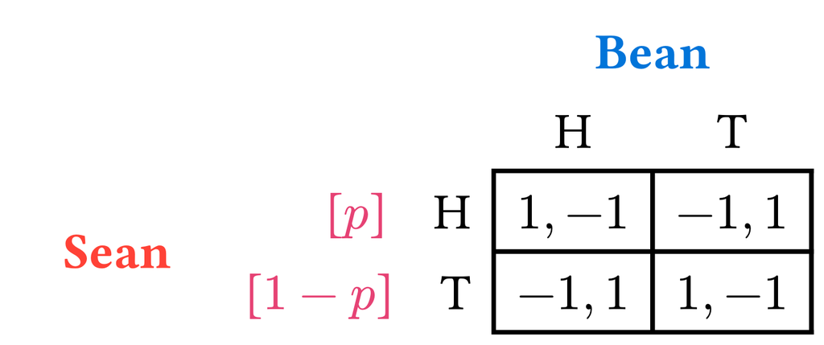

### When will Bean mix? (cont.)

- Recall: Sean’s strategy is $\sigma=pH+(1-p)T$
- Therefore, Bean will rationally play a mixed strategy when Sean is playing
  $$\sigma\left(p=\frac{1}{2}\right)=0.5H+0.5T$$
- **And**, we know that Sean will rationally play a mixed strategy when Bean is playing $\tau(\frac{1}{2})=0.5H+0.5T$
- …
- Therefore, each player can best-respond to each other with the strategy profile
  $$\left(\sigma(1/2), \tau(1/2)\right)=\left(0.5H+0.5T, 0.5H+0.5T\right)$$
- This is our Mixed Strategy Nash Equilibrium

## Next time

### What does this tell us?

- Let’s return to just before we solved for when Bean mixes

### What should Sean do?

- Sean can rationally play a mixed strategy when $q=\frac{1}{2}$
- I want you now to think of tau as a function
  - $\tau(\cdot)$ takes in a probability and spits out a particular mixed strategy
  - Our $\tau$ at the beginning was just an arbitrary output<sup>1</sup> of $\tau(q)$
- Sean can rationally mix when Bean is playing $\tau(1/2)$
- **Question**: what *should* Sean do?
  - There are a lot of mixed strategies Sean could play
    - Infinite of the form $\sigma=pH+(1-p)T$
  - Recall: We **know** (by assumption) that Sean is indifferent between playing Heads and playing Tails in response to $\tau(1/2)$
    - It turns out that Sean will be indifferent between Heads, Tails, and any mixed strategy in response to $\tau(1/2)$
[^4]: instance